# P2_explore_titanic_data

## 数据分析师纳米学位 P2：探索数据集

#### 首先载入 [泰坦尼克号数据集](https://www.kaggle.com/c/titanic/data) 和相关的函数库

```python
import numpy as np
import pandas as pd
import seaborn as sns
import matplotlib.pyplot as plt
%matplotlib inline
```

```python
!cat data_description_overview.txt
# 读取描述文件
```

[output not shown]

```python
titanic_data = pd.read_csv('titanic-data.csv')
titanic_data.head()
# 查看数据集顶端和底部
```

|  | PassengerId | Survived | Pclass | Name | Sex | Age | SibSp | Parch | Ticket | Fare | Cabin | Embarked |
| --- | --- | --- | --- | --- | --- | --- | --- | --- | --- | --- | --- | --- |
| 0 | 1 | 0 | 3 | Braund, Mr. Owen Harris | male | 22.0 | 1 | 0 | A/5 21171 | 7.2500 | NaN | S |
| 1 | 2 | 1 | 1 | Cumings, Mrs. John Bradley (Florence Briggs Th... | female | 38.0 | 1 | 0 | PC 17599 | 71.2833 | C85 | C |
| 2 | 3 | 1 | 3 | Heikkinen, Miss. Laina | female | 26.0 | 0 | 0 | STON/O2. 3101282 | 7.9250 | NaN | S |
| 3 | 4 | 1 | 1 | Futrelle, Mrs. Jacques Heath (Lily May Peel) | female | 35.0 | 1 | 0 | 113803 | 53.1000 | C123 | S |
| 4 | 5 | 0 | 3 | Allen, Mr. William Henry | male | 35.0 | 0 | 0 | 373450 | 8.0500 | NaN | S |

```python
titanic_data.tail()
```

|  | PassengerId | Survived | Pclass | Name | Sex | Age | SibSp | Parch | Ticket | Fare | Cabin | Embarked |
| --- | --- | --- | --- | --- | --- | --- | --- | --- | --- | --- | --- | --- |
| 886 | 887 | 0 | 2 | Montvila, Rev. Juozas | male | 27.0 | 0 | 0 | 211536 | 13.00 | NaN | S |
| 887 | 888 | 1 | 1 | Graham, Miss. Margaret Edith | female | 19.0 | 0 | 0 | 112053 | 30.00 | B42 | S |
| 888 | 889 | 0 | 3 | Johnston, Miss. Catherine Helen "Carrie" | female | NaN | 1 | 2 | W./C. 6607 | 23.45 | NaN | S |
| 889 | 890 | 1 | 1 | Behr, Mr. Karl Howell | male | 26.0 | 0 | 0 | 111369 | 30.00 | C148 | C |
| 890 | 891 | 0 | 3 | Dooley, Mr. Patrick | male | 32.0 | 0 | 0 | 370376 | 7.75 | NaN | Q |

#### 通过简单观察数据后可以发现：

- 数据集有891行，即记录了891名乘客的数据
- 数据包含了每名乘客幸存与否、票的等级、姓名、性别、年龄、船上同辈亲属的人数、船上父母子女的人数、船票号码、船票价格、船舱和上船地点的信息
- 数据中有一些缺失值(NaN)，需要先进行数据的清理

```python
num_of_nan = len(titanic_data) - titanic_data.count()
# 计算缺失值的个数
print num_of_nan
```

```
PassengerId      0
Survived         0
Pclass           0
Name             0
Sex              0
Age            177
SibSp            0
Parch            0
Ticket           0
Fare             0
Cabin          687
Embarked         2
dtype: int64
```

#### 调用count计算每一列缺失值的数量，发现NaN出现在年龄、船舱和上船地点三组数据中：

[output not shown]

- 所在船舱的数据缺失最多，在之后的数据分析中将不再考虑这一变量；
- 年龄数据大约缺失了20%，相对较少，此后的分析中依然会考虑年龄这个变量；
- 上船地点只丢失了两个数据，近似认为没有损失
- 其余数据都保持完整

#### 对于这个数据集，我最感兴趣的有两个问题：

- 船上乘客的结构是怎样的？如：
  - 乘客的性别和年龄比例是怎样的？
  - 不同等级的票分别占多少比例？
  - 每名乘客平均有多少亲属在船上？
  - 在不同地点上船的乘客比例有多少？
  - 乘客总体的生还率是多少？
- 船上乘客的生还率与哪些因素相关？如：
  - 是否与乘客的性别相关？
  - 是否与乘客的年龄相关？
  - 是否与船票的等级相关？
  - 是否与船上的亲属数量相关？

#### 本次报告会先分析船上乘客的结构，再研究与乘客生存率相关的因素

```python
# 本数据集中的性别不是数值量，为了计算便捷新增一列‘is_male'记录乘客的性别，0代表女性，1代表男性
titanic_data['is_male'] = titanic_data['Sex']=='male'
titanic_data['is_male'] = titanic_data['is_male'].apply(lambda x:int(x))
```

```python
titanic_data.describe()
```

|  | PassengerId | Survived | Pclass | Age | SibSp | Parch | Fare | is_male |
| --- | --- | --- | --- | --- | --- | --- | --- | --- |
| count | 891.000000 | 891.000000 | 891.000000 | 714.000000 | 891.000000 | 891.000000 | 891.000000 | 891.000000 |
| mean | 446.000000 | 0.383838 | 2.308642 | 29.699118 | 0.523008 | 0.381594 | 32.204208 | 0.647587 |
| std | 257.353842 | 0.486592 | 0.836071 | 14.526497 | 1.102743 | 0.806057 | 49.693429 | 0.477990 |
| min | 1.000000 | 0.000000 | 1.000000 | 0.420000 | 0.000000 | 0.000000 | 0.000000 | 0.000000 |
| 25% | 223.500000 | 0.000000 | 2.000000 | 20.125000 | 0.000000 | 0.000000 | 7.910400 | 0.000000 |
| 50% | 446.000000 | 0.000000 | 3.000000 | 28.000000 | 0.000000 | 0.000000 | 14.454200 | 1.000000 |
| 75% | 668.500000 | 1.000000 | 3.000000 | 38.000000 | 1.000000 | 0.000000 | 31.000000 | 1.000000 |
| max | 891.000000 | 1.000000 | 3.000000 | 80.000000 | 8.000000 | 6.000000 | 512.329200 | 1.000000 |

#### 对数据集调用describe方法，查看各列数据的统计值,可以得到如下信息：

- Survival：乘客总的生还比例是0.38
- Pclass：超过50%的乘客都是三等票，一等票的乘客不足25%
- Age：乘客的平均年龄是29.7岁，最年长的为80岁，最小的只有0.42岁
- Sibsp,Parch：乘客在船上平均有0.523个同辈亲属和0.38个父母或子女，船上大部分乘客都没有亲属
- Fare：船票的平均费用为32.2元，但超过75%的乘客船票费用都在平均数以下，最贵的船票达到了512元,最便宜的为0元
- is_male：船上男性乘客的数量更多，占比0.65

0元的船票有一些不符合常理，因此我希望先筛选出这些数据查看其中是否存在异常

```python
titanic_data[titanic_data['Fare']==0] #提取船费为0的乘客
```

|  | PassengerId | Survived | Pclass | Name | Sex | Age | SibSp | Parch | Ticket | Fare | Cabin | Embarked | is_male |
| --- | --- | --- | --- | --- | --- | --- | --- | --- | --- | --- | --- | --- | --- |
| 179 | 180 | 0 | 3 | Leonard, Mr. Lionel | male | 36.0 | 0 | 0 | LINE | 0.0 | NaN | S | 1 |
| 263 | 264 | 0 | 1 | Harrison, Mr. William | male | 40.0 | 0 | 0 | 112059 | 0.0 | B94 | S | 1 |
| 271 | 272 | 1 | 3 | Tornquist, Mr. William Henry | male | 25.0 | 0 | 0 | LINE | 0.0 | NaN | S | 1 |
| 277 | 278 | 0 | 2 | Parkes, Mr. Francis "Frank" | male | NaN | 0 | 0 | 239853 | 0.0 | NaN | S | 1 |
| 302 | 303 | 0 | 3 | Johnson, Mr. William Cahoone Jr | male | 19.0 | 0 | 0 | LINE | 0.0 | NaN | S | 1 |
| 413 | 414 | 0 | 2 | Cunningham, Mr. Alfred Fleming | male | NaN | 0 | 0 | 239853 | 0.0 | NaN | S | 1 |
| 466 | 467 | 0 | 2 | Campbell, Mr. William | male | NaN | 0 | 0 | 239853 | 0.0 | NaN | S | 1 |
| 481 | 482 | 0 | 2 | Frost, Mr. Anthony Wood "Archie" | male | NaN | 0 | 0 | 239854 | 0.0 | NaN | S | 1 |
| 597 | 598 | 0 | 3 | Johnson, Mr. Alfred | male | 49.0 | 0 | 0 | LINE | 0.0 | NaN | S | 1 |
| 633 | 634 | 0 | 1 | Parr, Mr. William Henry Marsh | male | NaN | 0 | 0 | 112052 | 0.0 | NaN | S | 1 |
| 674 | 675 | 0 | 2 | Watson, Mr. Ennis Hastings | male | NaN | 0 | 0 | 239856 | 0.0 | NaN | S | 1 |
| 732 | 733 | 0 | 2 | Knight, Mr. Robert J | male | NaN | 0 | 0 | 239855 | 0.0 | NaN | S | 1 |
| 806 | 807 | 0 | 1 | Andrews, Mr. Thomas Jr | male | 39.0 | 0 | 0 | 112050 | 0.0 | A36 | S | 1 |
| 815 | 816 | 0 | 1 | Fry, Mr. Richard | male | NaN | 0 | 0 | 112058 | 0.0 | B102 | S | 1 |
| 822 | 823 | 0 | 1 | Reuchlin, Jonkheer. John George | male | 38.0 | 0 | 0 | 19972 | 0.0 | NaN | S | 1 |

有15名乘客的船费为0元，在这15名乘客的其它数据中并没有信息的异常，推测可能为船费数据的缺失，因为数量不大，不影响后续的数据分析。

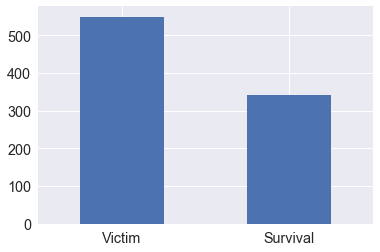

```python
fig,ax = plt.subplots(figsize=(6,4))
titanic_data['Survived'].value_counts().plot(kind='bar',fontsize='x-large')
ax.set_xticklabels(['Victim','Survival'],rotation='horizontal')
```

#### 画出船上乘客生存和遇难数量的柱状图，可以发现：

- 遇难乘客的人数远多于幸存者
- 大约有500多名乘客遇难，300多名乘客幸存

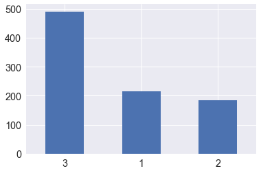

```python
fig,ax = plt.subplots(figsize=(6,4))
titanic_data['Pclass'].value_counts().sort_values(ascending=False).plot(kind='bar',fontsize='x-large',rot='horizontal')
```

#### 计算船上持有不同等级船票乘客的人数并绘制柱状图，可以发现：

- 持有三等票的乘客最多，有接近500名；
- 持有一等票和二等票的乘客人数差距不大，均为200名左右

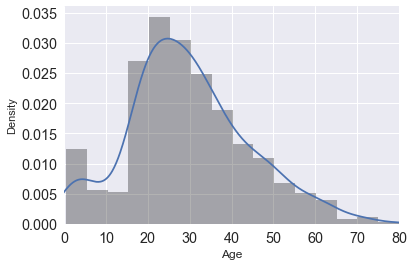

```python
fig,ax = plt.subplots(figsize=(6,4))
titanic_data['Age'].plot(kind='hist',bins=16,alpha=0.3,color='k',normed=True)
titanic_data['Age'].plot(kind='kde',fontsize='x-large',label='Age')
ax.set_xlim([0,80])
ax.set_xlabel('Age',fontsize='large')
```

#### 画出船上乘客标准化的年龄分布直方图和密度估计曲线，可以发现：

- 年龄分布是正偏态分布(Positive skewed)的
- 分布的峰值出现在20-25岁
- 0-5岁出现了一个反常的高值，10-15岁的人数比密度估计曲线偏低

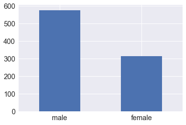

```python
fig,ax = plt.subplots(figsize=(6,4))
titanic_data['Sex'].value_counts().plot(kind='bar',fontsize='x-large',rot='horizontal')
```

#### 画出船上乘客性别分布的柱状图，可以发现

- 船上大部分乘客为男性(接近600名)，女性乘客大约只有300名

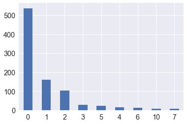

```python
fig,ax = plt.subplots(figsize=(6,4))
# 定义一个新的列'relatives' 记录乘客亲属的总人数
titanic_data['relatives'] = titanic_data['SibSp'] + titanic_data['Parch']
titanic_data['relatives'].value_counts().sort_values(ascending=False).plot(kind='bar',rot='horizontal',fontsize='x-large')
```

#### 计算船上乘客亲属的总人数(同辈亲属人数+父母子女人数)，画出船上乘客亲属数目的柱状图，可以发现：

- 有500多名乘客并没有亲属在船上，超过乘客总数的50%
- 不到200名乘客有一名亲属，大约100名乘客有两名亲属

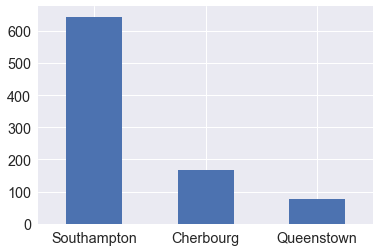

```python
fig,ax = plt.subplots(figsize=(6,4))
titanic_data['Embarked'].value_counts().plot(kind='bar',fontsize='x-large',rot='horizontal')
ax.set_xticklabels(['Southampton','Cherbourg','Queenstown'])
```

#### 画出船上乘客上船地点的柱状图，可以发现：

- 大部分乘客都在南安普顿登船，在皇后港登船的乘客最少

#### 以下开始分析与乘客生还率相关的因素，主要分析船票等级、年龄、性别和船上亲属个数几个自变量

```python
titanic_data.groupby('Survived')['Pclass','Age','relatives','is_male'].mean()
```

| Survived | Pclass | Age | relatives | is_male |
| --- | --- | --- | --- | --- |
| 0 | 2.531876 | 30.626179 | 0.883424 | 0.852459 |
| 1 | 1.950292 | 28.343690 | 0.938596 | 0.318713 |

#### 首先将数据集按“Survived”分组，对各组数据的均值进行粗略观察，可以发现：

- 船票等级和性别数据的均值在两组中存在比较大的差异
- 年龄和船上亲属总数数据的均值在两组数据中差距不大

```python
titanic_data[['Pclass','Age','relatives','is_male']].corr()
```

|  | Pclass | Age | relatives | is_male |
| --- | --- | --- | --- | --- |
| Pclass | 1.000000 | -0.369226 | 0.065997 | 0.131900 |
| Age | -0.369226 | 1.000000 | -0.301914 | 0.093254 |
| relatives | 0.065997 | -0.301914 | 1.000000 | -0.200988 |
| is_male | 0.131900 | 0.093254 | -0.200988 | 1.000000 |

观察自变量之间的相关性，发现这几个变量之间相关系数绝对值的最大值为0.37，没有出现显著的相关性  
因此本次数据分析过程中把它们都作为独立的自变量看待，不考虑自变量之间的相关性，也不同时考虑两个或更多自变量与生还率的相关关系

```python
titanic_data.groupby('Pclass')['Survived'].mean()
```

```
Pclass
1    0.629630
2    0.472826
3    0.242363
Name: Survived, dtype: float64
```

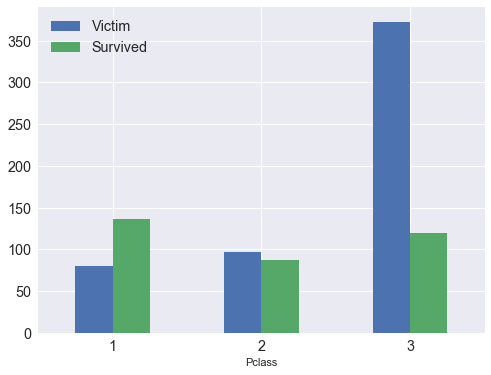

```python
pclass_tab = pd.crosstab(titanic_data['Pclass'],titanic_data['Survived'])
fig,ax = plt.subplots(figsize=(8,6))
pclass_tab.plot(kind='bar',fontsize='x-large',rot='horizontal',ax=ax)
ax.legend(['Victim','Survived'],fontsize='x-large')
```

```python
from scipy import stats
R_square,p,ddof,exp = stats.chi2_contingency(pclass_tab)
print 'R_square = {}\np = {}'.format(R_square,p)
```

```
R_square = 102.888988757
p = 4.5492517113e-23
```

#### 首先分析船票等级与生还率的相关性：

```python
def correlation_with_survival(group_key):
    print titanic_data.groupby(group_key)['Survived'].mean()
    print ''
    group_tab = pd.crosstab(titanic_data[group_key],titanic_data['Survived'])
    fig,ax = plt.subplots(figsize=(8,6))
    group_tab.plot(kind='bar',fontsize='x-large',rot='horizontal',ax=ax)
    ax.legend(['Victim','Survived'],fontsize='x-large')
    R_square,p,ddof,exp = stats.chi2_contingency(group_tab)
    print 'R_square = {}\np = {}'.format(R_square,p)
```

```
Sex
female    0.742038
male      0.188908
Name: Survived, dtype: float64

R_square = 260.717020167
p = 1.19735706278e-58
```

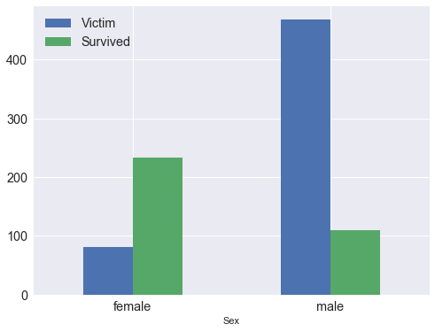

```python
correlation_with_survival('Sex')
```

#### 把分析过程定义为函数，调用函数研究性别与生还率的相关性：

```
Age_by_decade
0.0     0.612903
10.0    0.401961
20.0    0.350000
30.0    0.437126
40.0    0.382022
50.0    0.416667
60.0    0.315789
70.0    0.000000
80.0    1.000000
Name: Survived, dtype: float64

R_square = 20.9814626599
p = 0.00719683569785
```

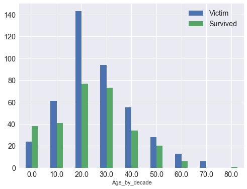

```python
# 把年龄按10岁为一段分组，创建新的一列'Age_by_decade'，其中0代表0-9岁，10代表10-19岁，以此类推
titanic_data['Age_by_decade'] = titanic_data['Age']//10*10
correlation_with_survival('Age_by_decade')
```

```python
# 排除<10岁乘客的数据，对其它乘客的年龄段与生还情况做Pearson独立性检验
age_tab = pd.crosstab(titanic_data['Age_by_decade'],titanic_data['Survived'])
R_square,p,ddof,exp = stats.chi2_contingency(age_tab.iloc[1:])
print 'R_square = {}\np = {}'.format(R_square,p)
```

```
R_square = 9.10360642719
p = 0.245302904151
```

#### 对于年龄数据，先按照10岁为一个年龄段分组，创建一个新的列，再调用函数分析乘客年龄与生还率的相关性：

```
relatives
0     0.303538
1     0.552795
2     0.578431
3     0.724138
4     0.200000
5     0.136364
6     0.333333
7     0.000000
10    0.000000
Name: Survived, dtype: float64

R_square = 80.6723134378
p = 3.57966897544e-14
```

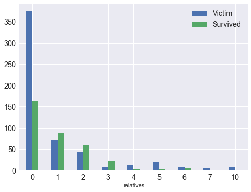

```python
correlation_with_survival('relatives')
```

#### 对船上亲属数量与生还率相关性的分析也是相似的：

- 把乘客按照‘relatives’分组后，可以看出有1-3名亲属在船上的乘客获救比例较高，没有亲属或者有3名以上亲属的乘客获救比例较低；
- 绘制有不同数量亲属的乘客生还与遇难人数的柱状图，也可以看出有1-3名亲属的乘客获救比例较高；
- 对‘relatives’和‘Survived’做独立性检验，得到的卡方检验值为81，对应可能性p=3.6e-14，拒绝原假设，即乘客的生还率与船上亲属人数相关

### 结论

#### 报告分析了泰坦尼克号上乘客的成员结构，并研究了乘客票的等级、性别、年龄和船上亲属数量几个变量与生存率的相关性，得到了如下结论：

- 泰坦尼克号上以男性乘客居多，年龄结构呈正偏态分布，超过50%的乘客持有的是三等票，大部分乘客在船上没有亲属，大约2/3的乘客在南安普顿上船
- 在灾难中幸存的乘客比例为0.38，通过统计分析的方法可以看出乘客的生还率与其船票等级、年龄、性别和船上亲属的数量相关：
  - 持有船票的等级越高，幸存比例越高；
  - 女性乘客在灾难中幸存的比例远高于男性；
  - 年幼的乘客(0-9岁)存活的比例比其他年龄段高，但对10岁以上的乘客，年龄与存活率之间没有体现出明显的相关性；
  - 船上有亲属的乘客存活比例高于没有亲属的乘客，有1-3名亲属的乘客存活比例最高，如果亲属多于4名，存活比例反而会下降；

影响乘客生存率的因素是复杂的，报告中只是对生存率与几个自变量进行了双变量分析，得到了几个与生存率相关的变量，而没有考虑多个自变量的共同作用，这样的分析显然还存在很多局限；同时，分析中找到了几个与生存率相关的变量，但仅仅是相关性我们不能确定这两个变量影响的顺序，也不能确定这样的相关性是否意味着因果关系，是不是有别的因素参与了其中。需要对数据进行进一步的分析，才能更深刻地了解影响泰坦尼克号乘客生存率的因素。